# 빅데이터수요예측

부산광역시 월별 어업총생산량 시계열 분석

이재용

```r
# Necessary package
library(fpp2)
theme_set(theme_grey(base_family='NanumGothic'))  # ggplot 한글 깨짐 방지
```

**Data: 2000.01-2021.12 부산광역시 월별 어업총생산량**

출처: KOSIS - 어업생산동향 총괄표

참고, 총 생산량에는 활어, 선어, 냉동이 포함되어있다. 어업별에는 일반해면어업, 천해양식어업, 원양어업, 내수면어업, 포경어업이 포함되어있다. 판매형태별에는 계통, 비계통이 포함되어있다.

### Data preprocessing

```r
# Into ts object
train <- ts(original_data[1:252], start=2000, frequency=12)
train
```

```
##        Jan   Feb   Mar   Apr   May   Jun   Jul   Aug   Sep   Oct   Nov   Dec
## 2000 55317 38141 32202 22870 14887 13780 12026 20345 33217 70832 53340 65746
## 2001 50313 33061 47249 23415 15571 11696 16208 31048 45600 73169 62491 70124
## 2002 53376 34557 30638 20602 14817  9793 13876 20296 34055 64854 64364 57075
## 2003 49187 28571 28396 14221 10023  8750 13098 18581 28847 64779 61930 55360
## 2004 40108 24378 17519 11559 10771  9191 13848 20892 37967 60380 78656 73007
## 2005 49853 26935 25352 16310 15623 27756 16338 24832 22802 47210 53292 49888
## 2006 45867 25177 22657 11784 11261 15520  9204 18382 31387 48777 40326 54149
## 2007 45328 24947 24547 19460  8997 14004 11474 20772 22891 45557 59039 66168
## 2008 49349 23141 28622 15424  8696 19247 15872 16659 31597 66897 75583 73414
## 2009 44826 35666 26206 11418 18608 17755 10857 26383 41168 49502 50515 68403
## 2010 45936 28002 16912  9424  7558 15142 12090 13773 27669 68489 43107 57326
## 2011 51636 26532 26580 12974 12256 15642 12669 20105 36591 64861 67656 85950
## 2012 63110 31840 27851  9225 12892 12209 13324 12552 18666 49265 35444 66052
## 2013 49048 14826 18855 11576  8826 11669 11419 18469 29343 33204 38420 73075
## 2014 44075 18146 18842 12563 13215 12883 11597 21231 27877 39038 46881 75836
## 2015 42522 25160 39976 24583  7526 25335 15880 26401 27420 27231 35911 65038
## 2016 49788 18374 16591 14137 10929 13132 10708 19241 26531 33809 51311 59499
## 2017 34780 20004 16631  6993 12243 14791 13065 25014 24748 17488 29069 48802
## 2018 42583 17814 25305 10234  7081 11607 20663 22295 43287 38390 50852 38021
## 2019 50844 19961 15461 11042 11854  9259 10135 16801 13053 17313 23468 57982
## 2020 30424 23847 17873  9213  8577  8493 13939 13190 17268 27528 28161 36397
```

```r
test <- ts(original_data[253:264], start=2021, frequency=12)
test
```

```
##        Jan   Feb   Mar   Apr   May   Jun   Jul   Aug   Sep   Oct   Nov   Dec
## 2021 26921 22861 20280 10476  7834  7092 14578 18112 29979 37579 34178 48377
```

### (1) Visualization

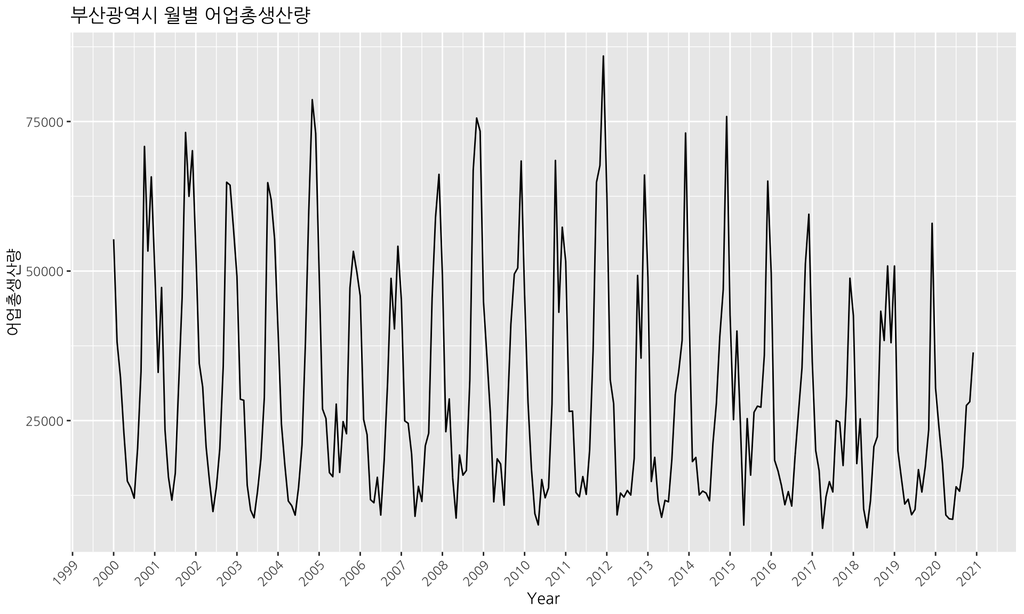

```r
autoplot(train) +
  ggtitle("부산광역시 월별 어업총생산량") +
  xlab("Year") +
  ylab("어업총생산량") +
  scale_x_continuous(breaks = scales::extended_breaks(20)) +
  theme(axis.text.x = element_text(angle = 45, hjust=1))
```

매년 초와 말에 생산량이 급증했다가 5-6월 쯤 생산량이 하락하는 패턴을 볼 수가 있다. 즉, 강한 seasonal 패턴이 있음을 한눈에 볼 수 있다.

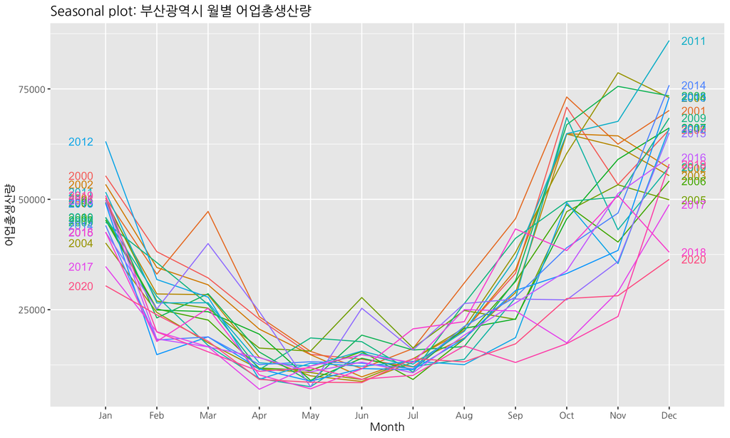

```r
ggseasonplot(train, year.labels = T, year.labels.left = T) +
  ylab("어업총생산량") +
  ggtitle("Seasonal plot: 부산광역시 월별 어업총생산량")
```

### (2) Transformation

위에 시계열 그래프를 보았듯이 이 데이터는 어느정도 constant variance를 가진 것을 볼 수 있다. 따라서 꼭 transformation을 하지 않아도 되어 보이지만 우선 r에서 제공하는 BoxCox.lambda() 함수를 통해 최적의 $\lambda$값을 구해 시계열 그래프를 그려 차이가 큰지를 확인해보기로 한다.

```r
(lambda <- BoxCox.lambda(train))
```

```
## [1] -0.009600045
```

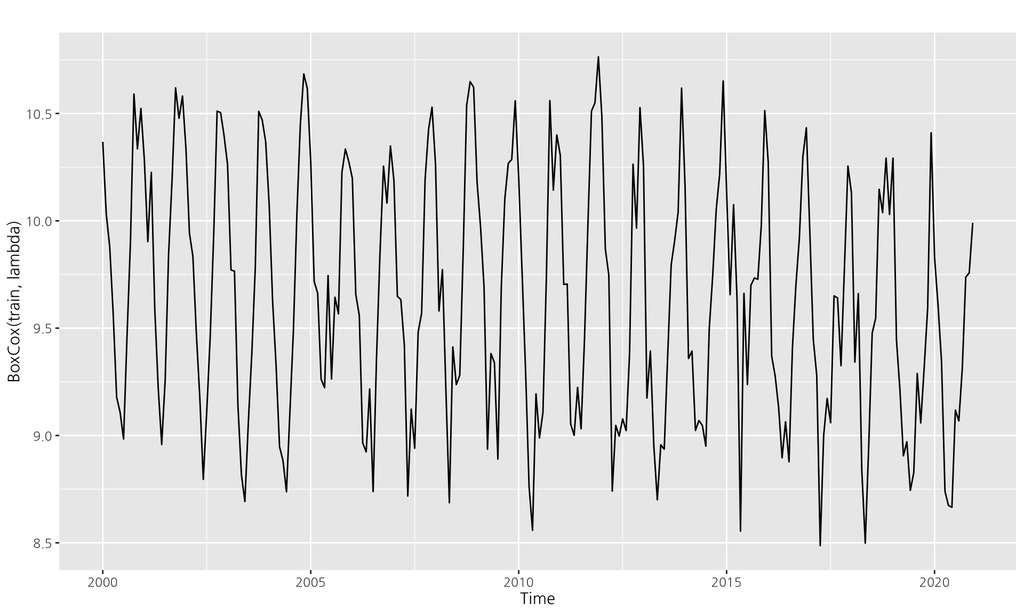

```r
autoplot(BoxCox(train,lambda))
```

전과 크게 차이가 없는 것을 보아 굳이 transformation을 하지 않아도 되어 보인다.

### (3) Seasonal naive prediction

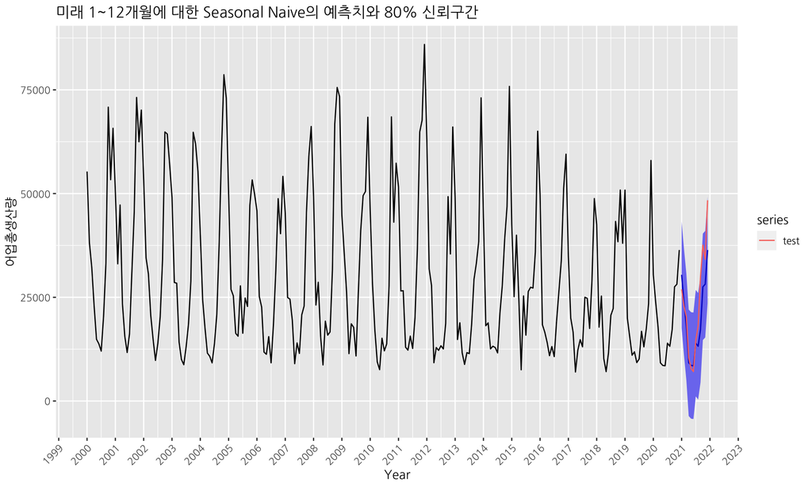

```r
fit1 <- snaive(train, h=12, level=80)
autoplot(train) +
  autolayer(fit1) +
  autolayer(test) +
  ggtitle("미래 1~12개월에 대한 Seasonal Naive의 예측치와 80% 신뢰구간") +
  ylab("어업총생산량") +
  scale_x_continuous(breaks = scales::extended_breaks(20)) +
  xlab("Year") +
  theme(axis.text.x = element_text(angle = 45, hjust=1))
```

### (4) STL decompostion

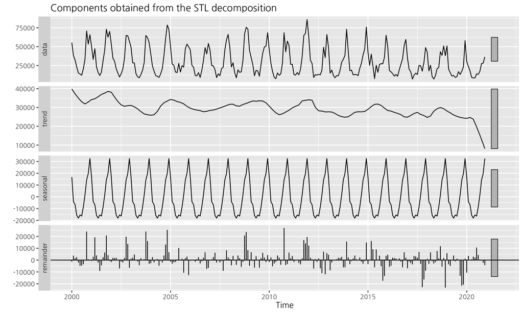

```r
train %>%
  stl(t.window=15, s.window="periodic", robust=T) %>%
  autoplot() +
  ggtitle("Components obtained from the STL decomposition")
```

Seasonal의 크기가 시점에따라 크게 변하지 않는 것을 봐서는 잘 분리가 되었다고 볼 수 있다. Remainder에도 데이터가 크게 남아 있지 않은 것을 봐서는 전반적으로 분해가 잘 된 것으로 판단된다. 마지막으로, Trend가 2020년 12월에 유난히 어업총생산량이 전년에 비해 급격히 하락한 것을 잘 잡아낸 것도 볼 수 있다.

### (5) Prediction based on STL decomposition

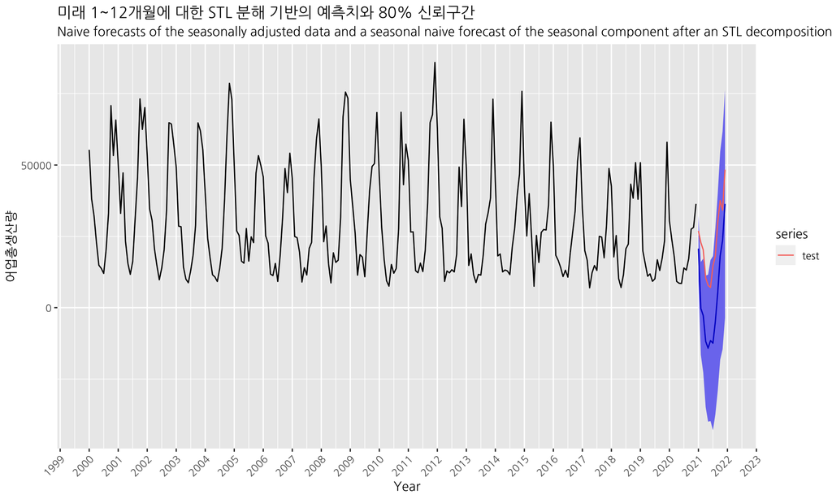

```r
fit2 <- stl(train, t.window=15, s.window="periodic", robust=T)
fit2 %>%
  forecast(method="naive", h=12, level=80) -> fit2
autoplot(fit2) +
  autolayer(test) +
  ylab("어업총생산량") +
  ggtitle("미래 1~12개월에 대한 STL 분해 기반의 예측치와 80% 신뢰구간") +
  labs(subtitle="Naive forecasts of the seasonally adjusted data and a seasonal naive forecast of the seasonal component after an STL decomposition") +
  scale_x_continuous(breaks = scales::extended_breaks(20)) +
  xlab("Year") +
  theme(axis.text.x = element_text(angle = 45, hjust=1))
```

### (6) Estimating an exponential smoothing model

```r
fit3 <- ets(train)
summary(fit3)
```

```
## ETS(M,N,M)
##
## Call:
##  ets(y = train)
##
##   Smoothing parameters:
##     alpha = 0.2715
##     gamma = 0.0013
##
##   Initial states:
##     l = 38683.3419
##     s = 2.1466 1.649 1.626 0.9715 0.6532 0.4669
##            0.5044 0.3781 0.461 0.8058 0.7969 1.5404
##
##   sigma:  0.2498
##
##      AIC     AICc      BIC
## 5824.970 5827.004 5877.912
##
## Training set error measures:
##                     ME     RMSE     MAE       MPE     MAPE     MASE      ACF1
## Training set -286.2528 7953.835 5606.25 -6.864868 21.00343 0.752732 0.1520921
```

ets() 함수의 default값인 model=“ZZZ” 인자값을 통해 information criterion을 최소화하는 기준으로 적합한 모델을 구하였다. 그 결과로 ETS(M,N,M) 모형이 적합되었다.

ETS(M,N,M) 모형은 multiplicative error에 Trend component는 없고 Seasonal component가 multiplicative인 모형이다. 따라서 smoothing parameter는 Trend의 것이 없고 $\hat{\alpha} = 0.2715$와 $\hat{\gamma} = 0.0013$이며 intial states 또한 Trend의 것이 없고 $\ell_0 = 38683.3419$와 $s_0 = 2.1466,s_1 = 1.649,...,s_{12} = 1.5404$ 뿐이다. 여기서 s가 12개인 이유는 monthly(12) 시계열 자료이기 때문이다.

$\hat{\gamma}$ 값이 작은 것의 의미는 seasonal component의 시간에 따른 변화가 매우 작다는 것이다.

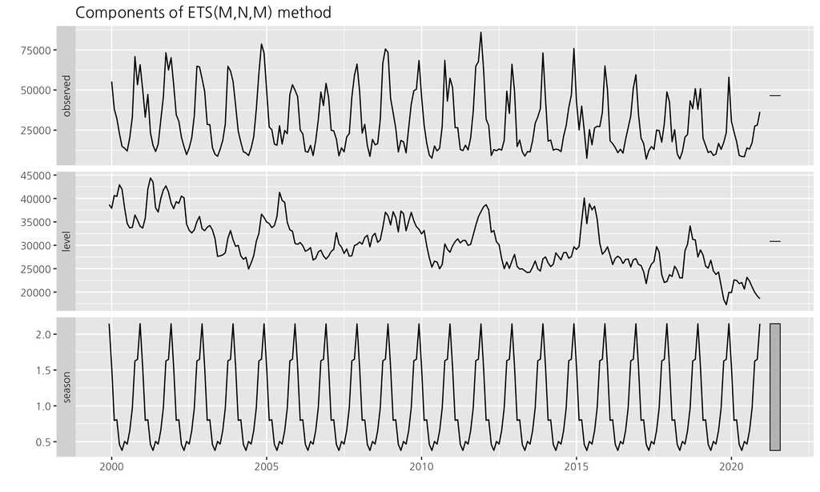

```r
autoplot(fit3)
```

Seasonal component의 variation이 일정한 것을 보면 분해가 잘 된 것을 볼 수 있다.

### (7) Prediction based on the estimated exponential smoothing model

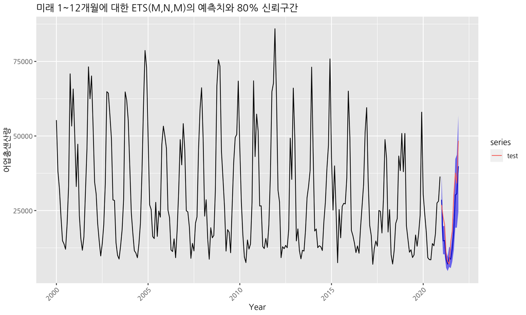

```r
fit3 %>% forecast(h=12, level=80, bootstrap=T) -> fit3
autoplot(fit3) +
  autolayer(test) +
  ylab("어업총샌산량") +
  ggtitle("미래 1~12개월에 대한 ETS(M,N,M)의 예측치와 80% 신뢰구간") +
  xlab("Year") +
  theme(axis.text.x = element_text(angle = 45, hjust=1))
```

Prediction intervals가 비교적 좁은 것을 보아 자료의 Seasonality가 강하기 때문에 예측이 비교적 수월했다는 것을 알 수 있다. 또한 “bootstrap=T” 인자를 통해 prediction intervals를 구할 때 resampled errors를 사용하게 되었다.

### (8) Comparison of results

```
## Seasonal naive: accuracy(fit1,test)
```

```
##                     ME      RMSE      MAE      MPE     MAPE     MASE      ACF1
## Training set -824.1375 10014.158 7447.871 -9.22457 29.40825 1.000000 0.3732747
## Test set     3613.0833  6390.736 4718.583 10.03619 17.79687 0.633548 0.5706380
##              Theil's U
## Training set        NA
## Test set     0.6513954
```

```
##
## Seasonally adjusted STL: accuracy(fit2,test)
```

```
##                      ME      RMSE       MAE        MPE      MAPE      MASE
## Training set  -137.8717  8987.737  6529.796  -5.490376  24.97194 0.8767332
## Test set     19298.8257 20239.953 19298.826 124.516105 124.51611 2.5911869
##                    ACF1 Theil's U
## Training set -0.2985690        NA
## Test set      0.1949097  3.849083
```

```
##
## Exponential smoothing: accuracy(fit3,test)
```

```
##                     ME     RMSE      MAE       MPE     MAPE      MASE      ACF1
## Training set -286.2528 7953.835 5606.250 -6.864868 21.00343 0.7527320 0.1520921
## Test set     4611.8658 6173.364 5272.447 17.714218 24.08055 0.7079134 0.1539464
##              Theil's U
## Training set        NA
## Test set     0.8727786
```

Test set의 RMSE를 기준으로는 Exponential smoothing이 가장 적은 수치를 보였다. 하지만 Test set의 ME, MAE, MPE, MAPE 와 MASE를 기준으로는 Seasonal naive가 모두 가장 적은 수치를 보였다. 따라서 해당 시계열 자료를 예측하는데에 있어 Seasonal naive의 모형이 가장 좋았음을 알 수 있고, 그다음으로는 Exponential smoothing이었다. Seasonally adjusted STL은 다른 방법들에 비해 매우 좋지 않은 성과를 보였다.